# CET and Mental Representations

Author

Isaias Ghezae

This is a brief overview of the research project I conducted as part of the Society of Personality and Social Psychology’s SPUR program.

I received a [Mamie Phipps Clark Research Grant](https://www.psichi.org/page/mamiephippinfo#.ZDsOf-zMKrc) from Psi Chi to conduct this research.

# Abstract

The U.S. Census Bureau estimates that by 2040 the population will be more diverse than it has ever been before. Current research in social psychology has found conflicting evidence for how this fact of demographic change is perceived by White individuals and its relationship with anti-immigrant attitudes. Additionally, recent work on demographic change has uncovered different potential mediators that may explain the relationship between demographic change and expressed political preferences (Perkins et al., 2022; Earle & Hodson, 2022), thus painting a more nuanced picture of this phenomenon. Moreover, arguments have recently been made in political psychology asserting that, in order to understand the relationship between perceived threat and political preferences, we need to be more specific about what types of threat are being considered when individuals are forming their political attitudes (Brandt & Bakker, 2022; Brandt et al., 2021). In light of this, the question of what factors might predict (negative) perceptions of immigrants will likely involve a more specific and nuanced consideration of which threats are relevant.

For this project, I was interested in how a specific political-cognitive antecedent known as collective existential threat (CET), defined as the perception and fear that the group one identifies with will cease to exist (Bai & Federico 2020, 2021), might be an especially important predictor for how immigrants are mentally represented amongst non-Hispanic White individuals from the United States. Specifically, I proposed that those with higher levels of CET will have more racialized, and potentially more negative[^1], mental representations of immigrants. These perceptions are potentially important since prior work has shown that whether immigrants are seen as looking White has implications for how people evaluate the likelihood that immigrants can successfully assimilate into the United States as well as how likely they are seen to be as a potential domestic threat (Kunst et al., 2018).

I recruited over 200 non-Hispanic White participants from the U.S. to generate mental representations of ‘Americans’ and ‘immigrants’ using the noise-based reverse correlation procedure (Figure 1 displays the experimental procedure). Generators were also given additional measures of political conservatism[^2] since I aimed to see if CET influences immigrant representations even when controlling for these variables. As recommended in recent reverse-correlation work, I created classification images (CIs) on the group-level (i.e., experimental condition), individual-level (each participant’s CI), and subgroup-level (by randomly averaging 10-15 individual-level CIs together). I then examine the effects that CET has on immigrant and American mental representations via independent coder trait ratings and pixel intensity analyses (focusing only on face pixels).

## References

Bai, H., & Federico, C. M. (2020). Collective existential threat mediates White population decline’s effect on defensive reactions. Group Processes & Intergroup Relations, 23(3), 361-377.

Bai, H., & Federico, C. M. (2021). White and minority demographic shifts, intergroup threat, and right-wing extremism. Journal of Experimental Social Psychology, 94, 104114.

Brandt, M. J., & Bakker, B. N. (2022). The complicated but solvable threat–politics relationship. Trends in Cognitive Sciences.

Brandt, M. J., Turner-Zwinkels, F. M., Karapirinler, B., Van Leeuwen, F., Bender, M., van Osch, Y., & Adams, B. (2021). The association between threat and politics depends on the type of threat, the political domain, and the country. Personality and social psychology bulletin, 47(2), 324-343.

Earle, M., & Hodson, G. (2022). Dealing with declining dominance: White identification and anti-immigrant hostility in the US. Group Processes & Intergroup Relations, 25(3), 727-745.

Kunst, J. R., Dovidio, J. F., & Dotsch, R. (2018). White look-alikes: Mainstream culture adoption makes immigrants “look” phenotypically white. Personality and Social Psychology Bulletin, 44(2), 265-282.

Perkins, K. M., Toskos Dils, A., & Flusberg, S. J. (2022). The perceived threat of demographic shifts depends on how you think the economy works. Group Processes & Intergroup Relations, 25(1), 227-246.

# Figures

## Figure 1

### Phase 1: Generate CIs

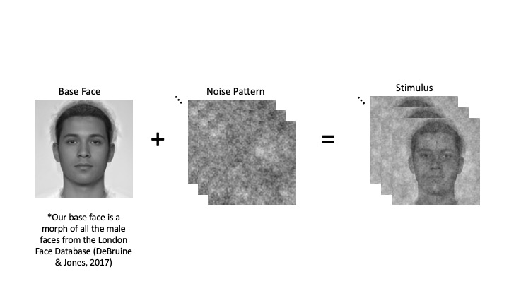

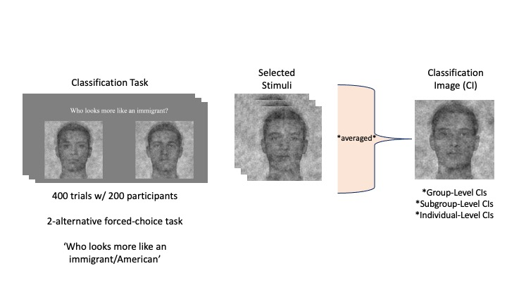

### Phase 2: Rate and Analyze CIs

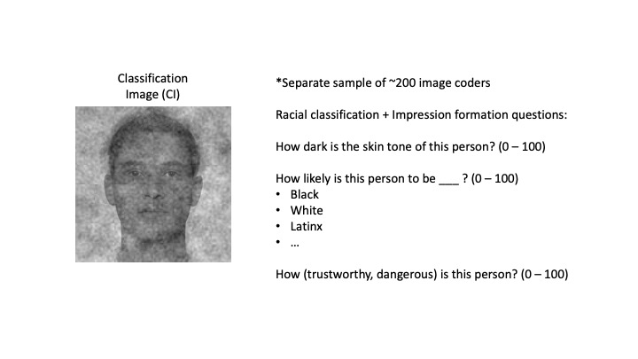

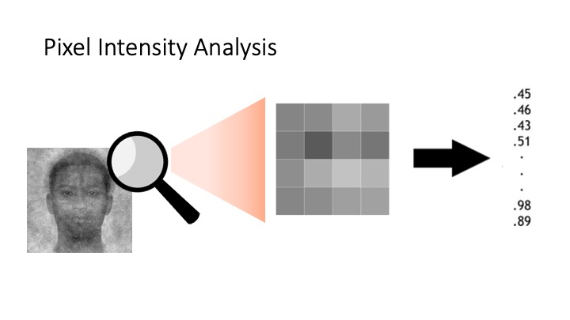

## Figure 2

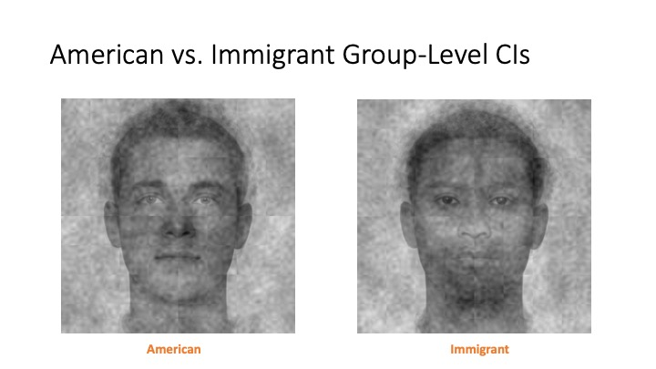

## Figure 3

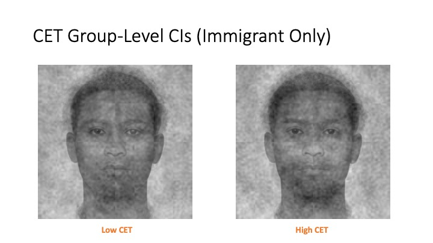

## Figure 4

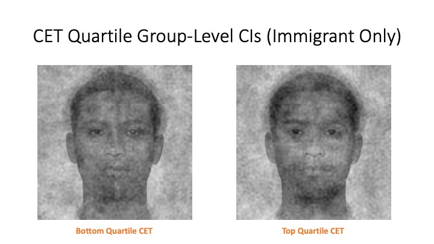

# Analyses

**Distribution of CET Scores**

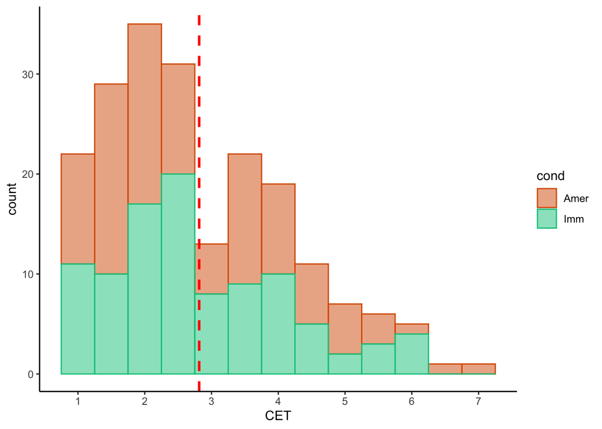

**CET scores between High CET and Low CET - Immigrant Condition Only**

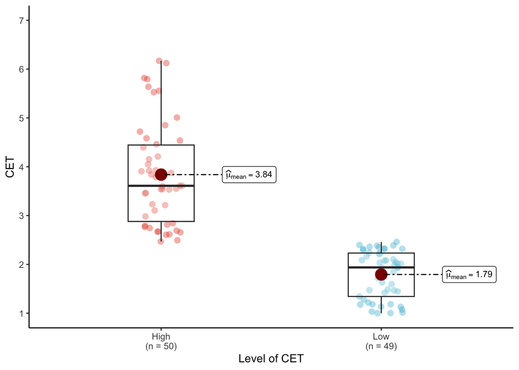

**Scale Correlation Matrix (N = 202)**

- FRS = Measure of Far-Right Support (2 items); higher FRS means greater far right support
- IDEO = Measure of political ideology (1-item slider on an 11-point scale); higher IDEO means greater conservatism
- SDO = Social Dominance Orientation (8 items)
- CET = Collective Existential Threat (13 items)

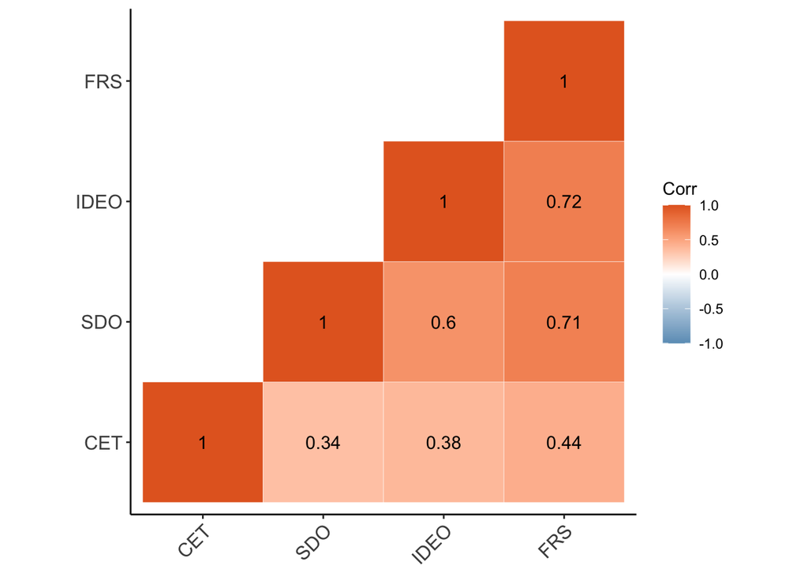

**Scale Correlation Matrix - Immigrant Condition Only (N = 99)**

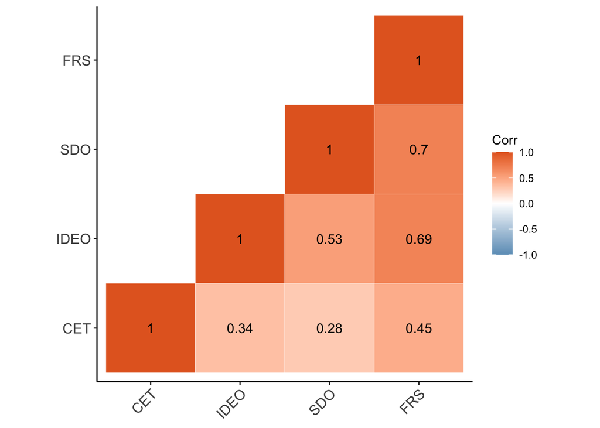

**Scatter plot displaying relationship between CET and Pixel Intensity Scores (within immigrant condition only)**

- Higher pixel intensity scores indicate *lighter* images.

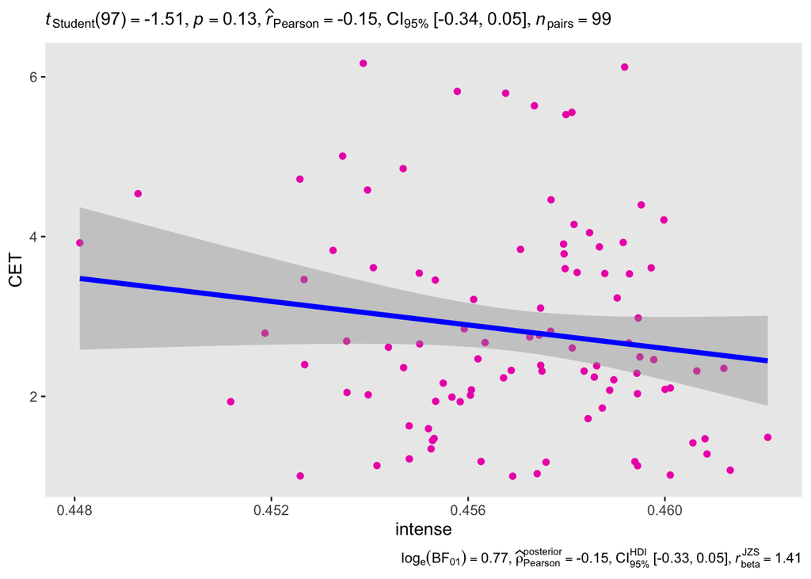

**Pixel Intensity Density Plots Split by Quartile – Imm Only**

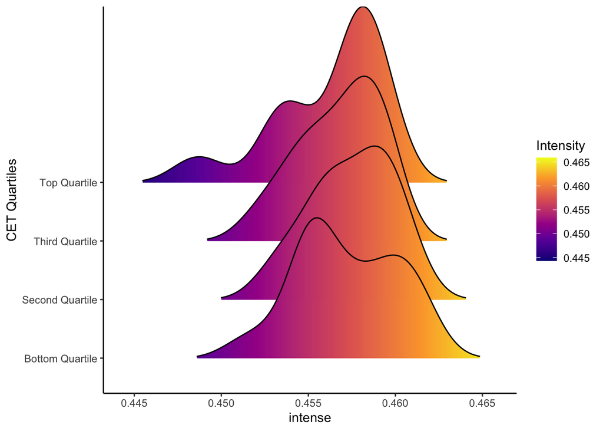

## Footnotes

[^1]: As measured by negative trait ratings in phase 2 of the reverse-correlation study (e.g., less trustworthy, more dangerous)
[^2]: These were Social Dominance Orientation, far-right support, and political ideology (11-point scale).